# Who stays in the hospital for 5 days or more? Diabetes encounters by age and race

Dominic Rueck

## Data

- **Fairness:** Diabetes Hospital, 1999-2008. One row is one hospital encounter of a patient with diabetes. My file has 5,000 rows.
- **Sports:** Setka Cup table tennis. One row is one match. My file has 7,851 rows.

## Older patients more often stay 5 days or more, in every race

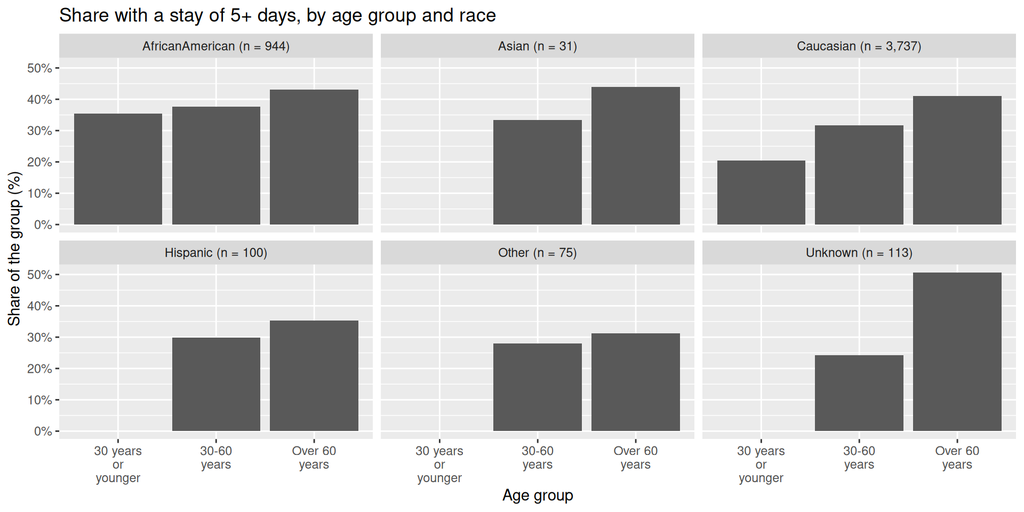

Figure 1

## Compared to what? Group means barely differ next to single encounters

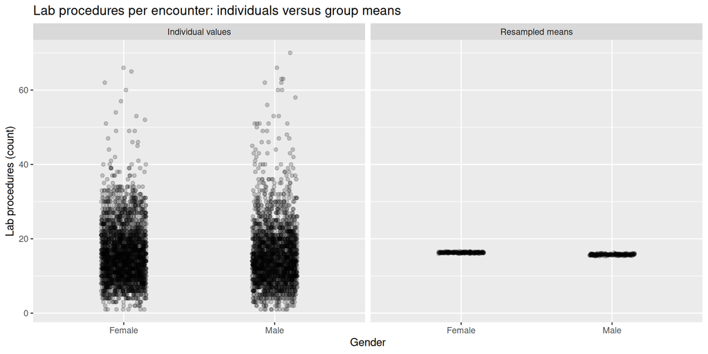

Figure 2

## Quick change of scenery: In table tennis, the home player wins about half of all matches

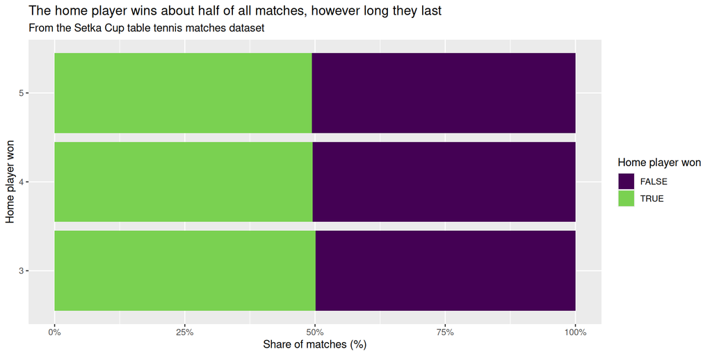

Figure 3

## What it shows, and its limits

- The share of long stays differs by age group, and the pattern looks the same for all of the races. This describes a difference, not a cause.
- A stay of 5 or more days is my own cutoff, and the data cover US hospitals from 1999 to 2008, so they say nothing about today.
- In the Sports data, “home player” probably only means the first-listed player, so a 50% win rate is not evidence for a real home advantage.

## Sources and AI use

**Fairness:** Clore, J., Cios, K., DeShazo, J., & Strack, B. (2014). Diabetes 130-US Hospitals for Years 1999-2008 [Dataset]. UCI Machine Learning Repository. https://doi.org/10.24432/C5230J.

**Sports:** Cassidy, G. (2024, July 17). Setka table tennis dataset – SCORE sports data repository. Scorenetwork.Org. https://data.scorenetwork.org/table_tennis/table_tennis_sept2022.html

- AI use: None